# Data Visualization with R

# Creating a Scatter Plot

```r
require(dplyr)
require(ggplot2)
require(qdata)
data(bands)
```

Scatter plots are used to display the relationship between two continuous variables. Axes represent a variable each, while each point represents an observation. This plot is often the first way to describe data when you look at it.

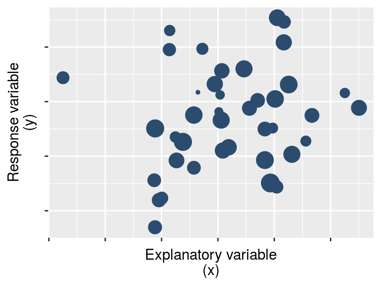

This chapter presents how to build scatter plots and introduces some basic concept of `ggplot2` grammar: aesthetic mappings and layers.

## The first scatter plot

Suppose you are interested in the relationship between the humidity and the viscosity in the `bands` dataset.

```r
ggplot(data=bands, mapping=aes(x=humidity, y=viscosity)) +
  geom_point()
```

[output not shown]

The syntax is quite simple. The function `ggplot()` initializes the plot with the following parameters:

- *data* refers to the dataframe to use for the plot, in this case is the `bands` data frame
- *mapping* refers to the list of aesthetic mappings (visual properties) to use for plot, passed as arguments of the `aes()` function. In this case you *map* the data to *aesthetics* of plot like follow: the *x*-axis displays the `humidity` variable and the *y*-axis displays the `viscosity` variable.

Notes:

- the variable names must be unquoted
- the function is named `ggplot()` while the package is named `ggplot2`

The `ggplot()` function does not return anything. You have to add to `ggplot()`, which geometric object (*geom*) you want to add. A scatter plot is made by points, and so you will use the `geom_point()` function, without any argument.

The meaning of technical terms will be cleared in the following examples.

Alternatively, the plot can be initialized with `ggplot()` without any argument and the same arguments have to be passed to `geom_point()`.

```r
ggplot() +
  geom_point(data=bands, mapping=aes(x=humidity, y=viscosity))
```

[output not shown]

To understand the difference between the two examples above, you can add a new `geom` to the plot. From the previous plot it appears a (weak) positive correlation between the variables. A regression line can be added to the plot. The `geom_smooth()` with `method="lm"` adds a regression line based on the linear model.

```r
ggplot(data=bands, mapping=aes(x=humidity, y=viscosity)) +
  geom_point() +
  geom_smooth(method="lm")
```

[output not shown]

You can try to add a smoother to the plot, but starting from the code with `ggplot()` without arguments.

```r
ggplot() +
  geom_point(data=bands, mapping=aes(x=humidity, y=viscosity)) +
  geom_smooth(method="lm")
```

[output not shown]

```r
ggplot() +
  geom_point(data=bands, mapping=aes(x=humidity, y=viscosity)) +
  geom_smooth(data=bands, mapping=aes(x=humidity, y=viscosity), method="lm")
```

[output not shown]

To sum up, data and aesthetics specified in `ggplot()` are used by default by all layers. Layers are like tracing papers, you can overlay them. Each layer contains a geometry. If a layer has its own data and/or aesthetics, that layer will ignore the default values.

## Assigning `ggplot`s to a variable

From a formal point of view, a ggplot is an R object like anything else; so you can assign it to a variable.

```r
gp1 <- ggplot(data=bands, mapping=aes(x=humidity, y=viscosity)) +
  geom_point()
```

And now you can recall the plot named `gp1`.

```r
gp1
```

[output not shown]

*Note*: you can print the plot by recalling it; indeed the run of `gp1` does the same work of `print(gp1)` command.

Once you assigned the scatter plot to `gp1`, you can add to this plot a smoother by doing:

```r
gp2 <- gp1 +
  geom_smooth(method="lm")
gp2
```

[output not shown]

## Changing the shape and size of points

At this point, you probably are interested to change the aspect of points like shape or size: it suffices to set the `shape` or the `size` as a parameter of `geom_point()`.

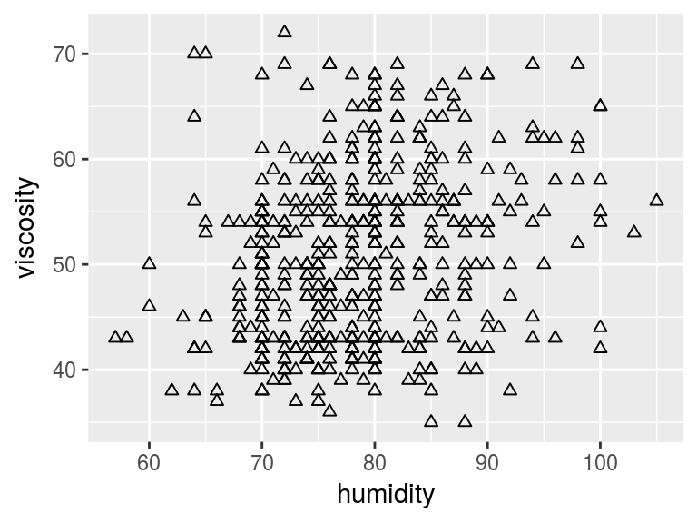

```r
ggplot(data=bands, mapping=aes(x=humidity, y=viscosity)) +
  geom_point(shape=2)
```

The following shapes are available in R graphics. Point shapes from 0 to 14 have just an outline, shapes from 15 to 20 are solid and shapes from 21 to 25 have both an outline and a fill. Default shape for `ggplot2` graphics is 16.

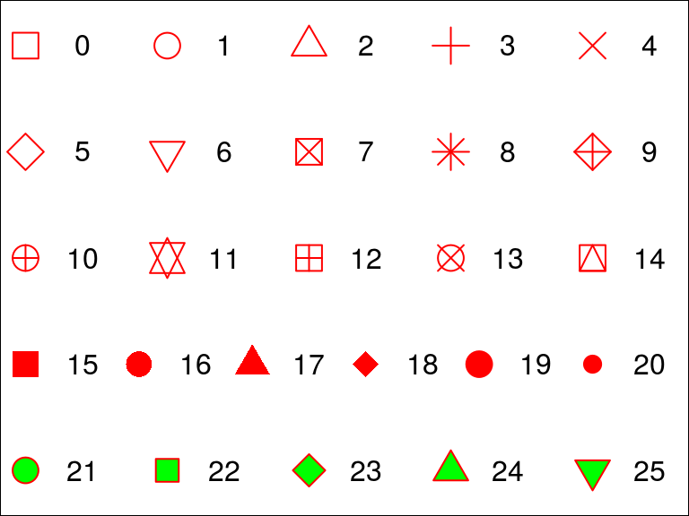

Shape can also be a (single) character string.

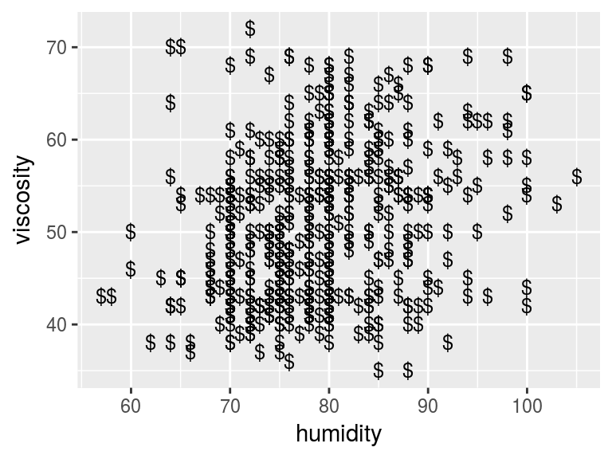

```r
ggplot(data=bands, mapping=aes(x=humidity, y=viscosity)) +
  geom_point(shape="$", size=3)
```

The same way works for `size` too.

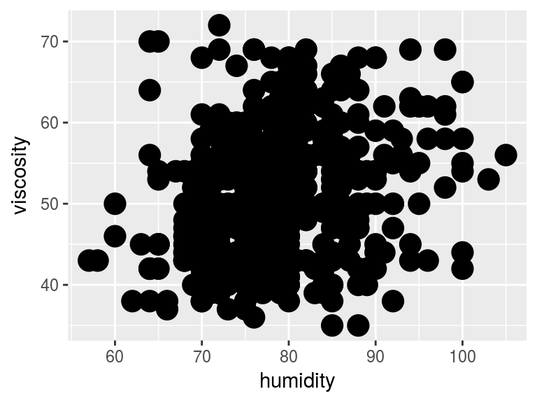

```r
ggplot(data=bands, mapping=aes(x=humidity, y=viscosity)) +
  geom_point(size=5)
```

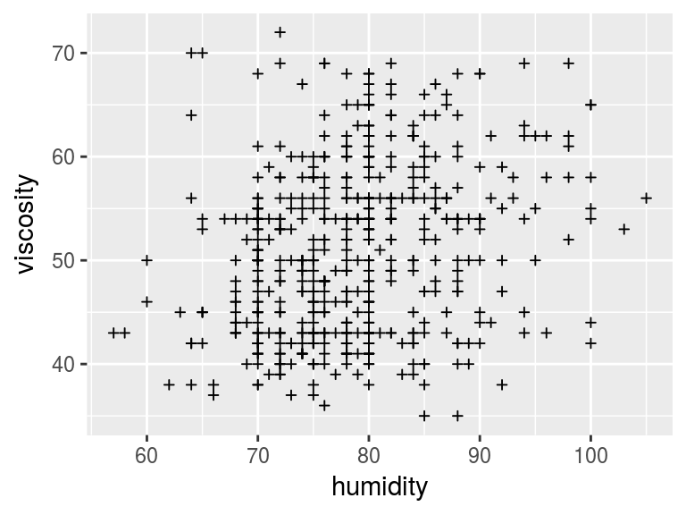

```r
ggplot(data=bands, mapping=aes(x=humidity, y=viscosity)) +
  geom_point(shape=3, size=1)
```

## Changing the colour of points

Colour can be set in a similar way than `shape` and `size`: setting `colour` as a `geom_point()` parameters. Both UK and US spellings (`color`) can be used.

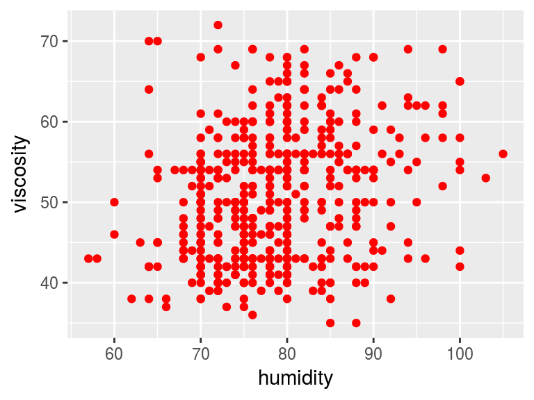

```r
ggplot(data=bands, mapping=aes(x=humidity, y=viscosity)) +
  geom_point(colour="red")
```

Shapes from 21 to 25 allow two colours. In these cases, `colour` set the outline and `fill` set the internal colour.

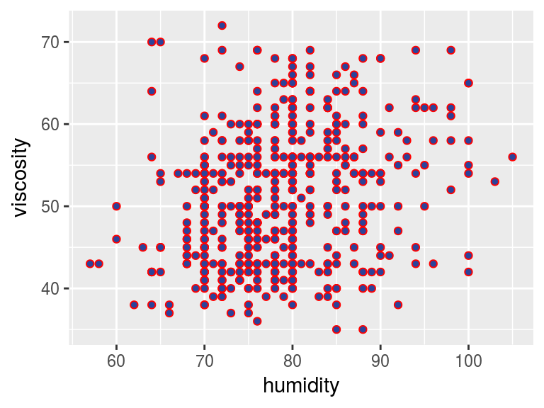

```r
ggplot(data=bands, mapping=aes(x=humidity, y=viscosity)) +
  geom_point(shape=21, colour="red", fill="#2b439a")
```

When you need to pass a colour to R, you can use a string with the colour name. There are 657 colour names in R; just type `colours()` to view them. Alternatively, you can pass a string with the hexadecimal code (e.g. “#2b439a”) or you can use `rgb()`, `hsv()` or `hcl()` if you are familiar with these colour models.

Data used in these examples has 540 observations but the plot seems have less points. This is because many points overlap. Transparencies are useful in this cases. The `alpha` aesthetic set the transparency level: legal `alpha` values are any numbers from 0 (transparent) to 1 (opaque).

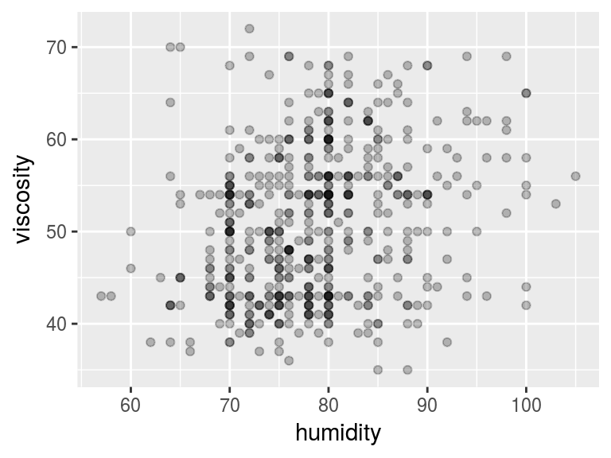

```r
ggplot(data=bands, mapping=aes(x=humidity, y=viscosity)) +
  geom_point(alpha=0.25)
```

Since `alpha=0.25` (and 0.25 is 1/4) a point will be drawn as solid when four points overlap.

If you are familiar with base graphics in R, `shape` substitutes `pch`, `size` substitutes `cex`, `colour` substitutes `col` and `fill` substitutes `bg`. The base syntax can be used also in `ggplot2` but it is strongly suggested to migrate to the new and more intuitive syntax.

## Mapping a third variable to scatter plots

Scatter plots were born to visualize the relationship between two variables: one mapped to the x-axis and one mapped to the y-axis. Sometimes, a third variable should be visualized. In these case, you can map a third variable to other aesthetics: size, shape or colour.

Suppose you’re interested in the relationship between humidity and viscosity accordingly the presence or absence of `band_type`. `band_type` is a discrete variable so to perform this task, you can map it to `colour`.

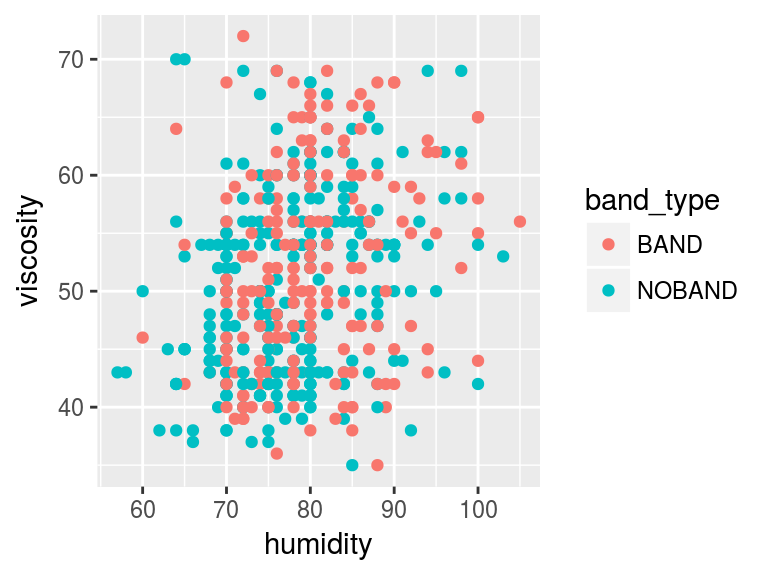

```r
ggplot(data=bands, mapping=aes(x=humidity, y=viscosity, colour=band_type)) +
  geom_point()
```

Note that mapping occurs within `aes()`, while setting occurs outside of `aes()`.

The plot shows the same points that previous ones with different colours and a legend will be added.

Alternatively, you can map `band_type` to another aesthetic, like `shape`.

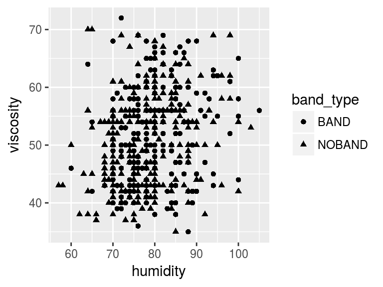

```r
ggplot(data=bands, mapping=aes(x=humidity, y=viscosity, shape=band_type)) +
  geom_point()
```

Since different shapes are more difficult to read when you have many points, this solution provide an alternative when you are printing in black and white, without colours. You can improve your result using both aesthetics together.

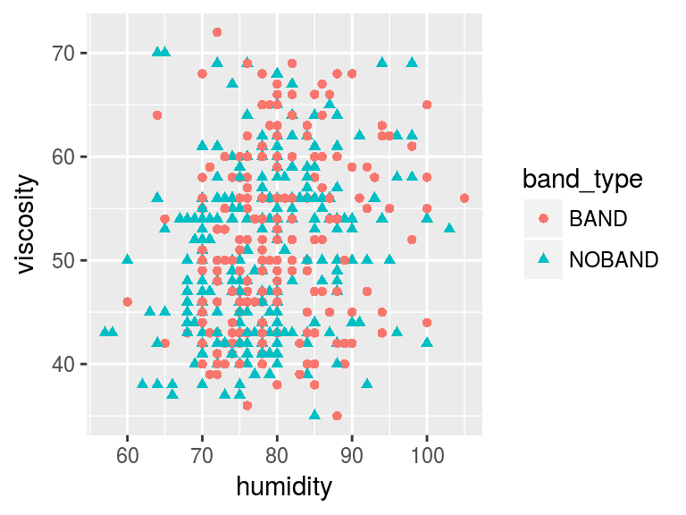

```r
ggplot(data=bands, mapping=aes(x=humidity, y=viscosity, colour=band_type, shape=band_type)) +
  geom_point()
```

Mapping a discrete variable to `size` aestethic is not advised.

If you’re interested in a continuous variable as third variable you can `map` it to `colour` or to `size`. It makes no sense map a continuous value to `shape`. Let us consider `ink_pct` as third variable:

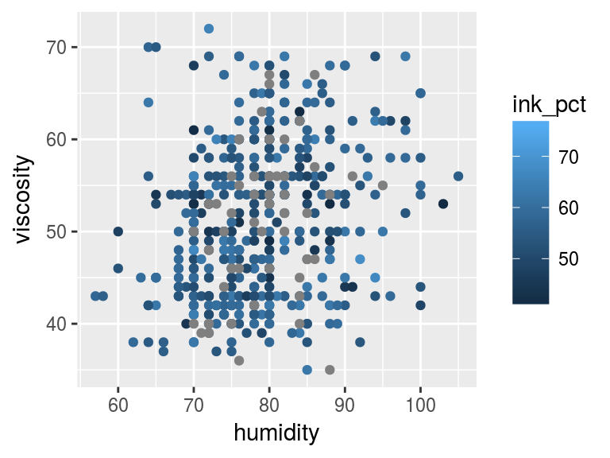

```r
ggplot(data=bands, mapping=aes(x=humidity, y=viscosity, colour=ink_pct)) +
  geom_point()
```

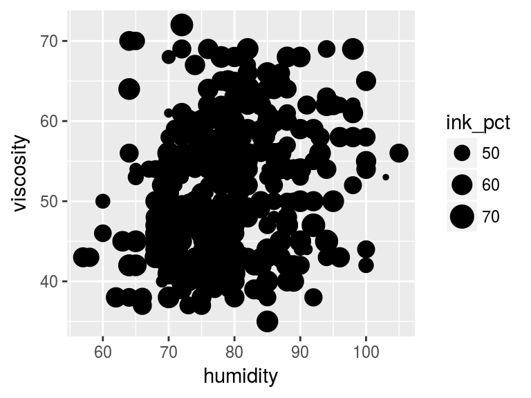

```r
ggplot(data=bands, mapping=aes(x=humidity, y=viscosity, size=ink_pct)) +
  geom_point()
```

It is more difficult perceiving small differences in size and colour, so variable mapped to these aesthetic attributes will be interpreted with a much lower accuracy than those mapped to spatial coordinates (`x` and `y`).

The following code will produce a scatter plot of `humidity` versus `viscosity` with `band_type` mapped to `colour`.

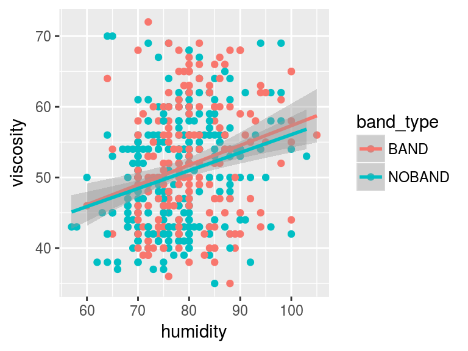

```r
ggplot(data=bands, mapping=aes(x=humidity, y=viscosity, colour=band_type)) +
  geom_point() + geom_smooth(method="lm")
```

The scatter plot has two regression lines. This is the expected results, as `band_type` is mapped to `colour` in the `ggplot()` function and its arguments are used not only by `geom_point()` but also by `geom_smooth()`.

To produce a scatter plot with a single regression line the `colour` aesthetic must be mapped only to `geom_point()`.

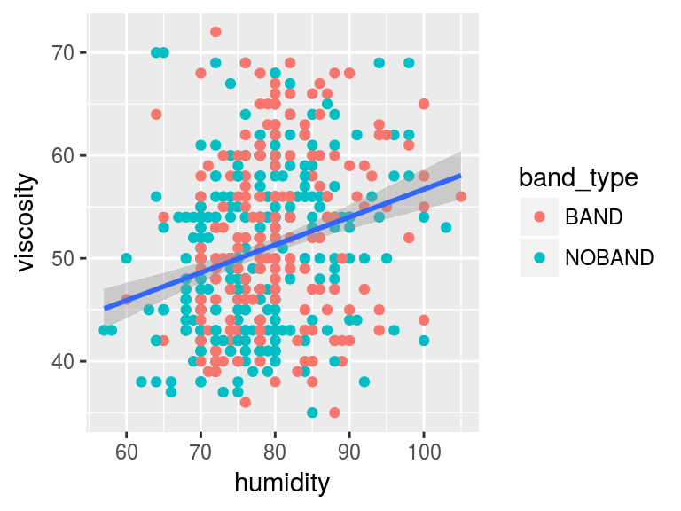

```r
ggplot(data=bands, mapping=aes(x=humidity, y=viscosity)) +
  geom_point(mapping=aes(colour=band_type)) +
  geom_smooth(method="lm")
```

Finally, this is the plot if you are interested to three regression line, one for all values and one for each level of `band_type`.

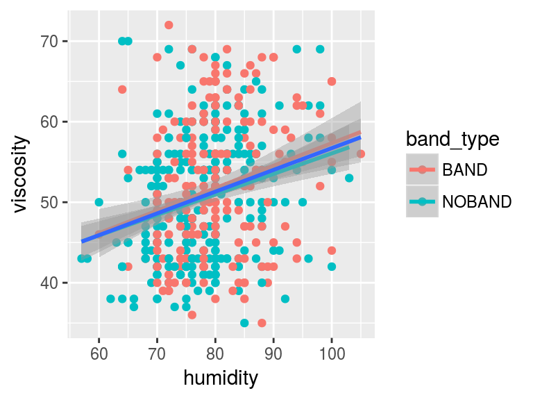

```r
ggplot(data=bands, mapping=aes(x=humidity, y=viscosity)) +
  geom_point(mapping=aes(colour=band_type)) +
  geom_smooth(mapping=aes(colour=band_type), method="lm") +
  geom_smooth(method="lm")
```

## Mapping four variables to scatter plots

Although the interpretation may be difficult, different variable can map to different aesthetics at the same time. From a theoretical point of view you can map as many variable as the number of aesthetics, but it is not suggested map more than four variable.

This is the result when you are interested to the ink percentage and band type, at the same time.

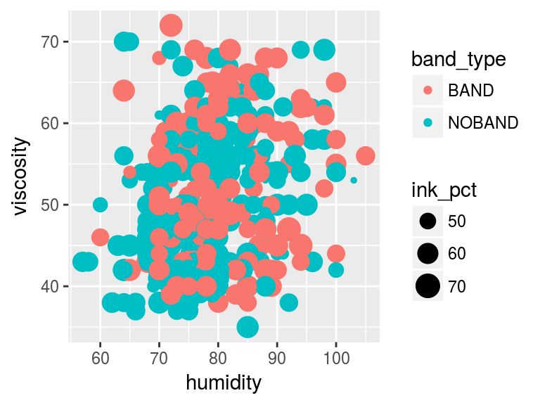

```r
ggplot(data=bands, mapping=aes(x=humidity, y=viscosity, size=ink_pct, colour=band_type)) +
  geom_point()
```

When a variable is mapped to `size` it is not suggested to map another variable to `shape`. This is because it is difficult to compare the sizes of different shapes.